# Analysis of 2022 Indiana Terminated Pregnancy Reports

Ted Schurter

2023-07-14

#### Total abortions in Indiana rose 13% to 9,529 in 2022, boosted by a 293% increase in nonresident abortions from women in neighboring states fleeing state abortion bans implemented following the elimination in June 2022 of federal abortion protection by the [Supreme Court](https://www.supremecourt.gov/opinions/21pdf/19-1392_6j37.pdf). Abortions to Indiana residents declined 3% even as the impact of the state’s own ban was [blunted](https://apnews.com/article/abortion-health-indiana-legislature-9dda020bf811f19e6254915ca1324edc) by a lawsuit that preserved abortion access while litigation continued.

#### While the Indiana Supreme Court recently [upheld](https://apnews.com/article/indiana-abortion-ban-dc149c0716e3cf5be604bb5f427db7b8) that ban, the impact of the shifting legal landscape in and around Indiana is reflected in 2022’s volatile monthly abortion totals. Although they climbed above last year’s levels in February and remained there through September, they spiked much higher in July, the first month after the Dobbs decision ended federal abortion protection, reaching 1,182, 66% higher than July 2021.

### Chart

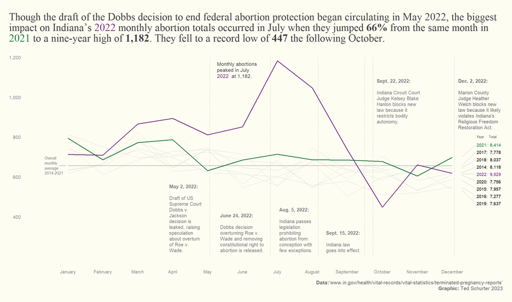

### Data

| Year | Month | Resident abortions | Nonresident abortions | Total abortions |
| --- | --- | --- | --- | --- |
| 2022 | January | 670 | 42 | 712 |
| 2022 | February | 667 | 42 | 709 |
| 2022 | March | 823 | 42 | 865 |
| 2022 | April | 764 | 129 | 893 |
| 2022 | May | 743 | 67 | 810 |
| 2022 | June | 717 | 134 | 851 |
| 2022 | July | 778 | 404 | 1182 |
| 2022 | August | 670 | 376 | 1046 |
| 2022 | September | 472 | 265 | 737 |
| 2022 | October | 378 | 69 | 447 |

[output cut: 98 more lines]